# PLS - Agencias

Artículo 1 (versión 2)

Roberto Gil-Saura

2/4/2021

NOTA: Modelo completo, pero quitamos LOY3.

# 1 Consideraciones sobre la muestra

# 2 Modelización

Seguidamente mostramos el modelo de medida (outer model) y el modelo estructural (inner model), establecidos a partir de las hipótesis lanzadas.

El modelo de medida es el siguiente:

[interactive chart not shown]

Modelo de medida

El modelo estructural es el siguiente:

[interactive chart not shown]

Modelo estructural

## 2.1 Análisis de la fiabilidad

Para el modelo de medida se han considerado constructos reflectivos. De este modo, el primer paso debe ser observar el resumen de los indicadores de fiabilidad, consistencia interna y validez.

El resultado del análisis muestra todas las escalas que apoyan las variables latentes tienen un *Cronbach’s alpha* mayor que 0.7, completado por una fiabilidad del compuesto *rhoC* también por encima de 0.7. para valores superiores a 0.9[^1].

```
             alpha    rhoC     AVE    rhoA
ICT        "0.891" "0.922" "0.707" "0.910"
VCC        "0.829" "0.864" "0.524" "0.877"
TRUST      "0.842" "0.905" "0.762" "0.854"
COMMITMENT "0.894" "0.926" "0.758" "0.896"
SOCSAT     "0.832" "0.898" "0.748" "0.884"
ECOSAT     "0.789" "0.880" "0.712" "0.796"
LOY        "0.839" "0.903" "0.757" "0.843"

Alpha, rhoC, and rhoA should exceed 0.7 while AVE should exceed 0.5
```

## 2.2 Validez convergente

### 2.2.1 AVE

Del mismo modo, para evaluar la *validez convergente* o grado con el que una medida correlaciona positivamente con medidas alternativas del mismo constructo, usamos el coeficiente *AVE (average variance extracted)* que también cumple con la expectativa de estar por encima de 0.5.

```
             alpha    rhoC     AVE    rhoA
ICT        "0.891" "0.922" "0.707" "0.910"
VCC        "0.829" "0.864" "0.524" "0.877"
TRUST      "0.842" "0.905" "0.762" "0.854"
COMMITMENT "0.894" "0.926" "0.758" "0.896"
SOCSAT     "0.832" "0.898" "0.748" "0.884"
ECOSAT     "0.789" "0.880" "0.712" "0.796"
LOY        "0.839" "0.903" "0.757" "0.843"

Alpha, rhoC, and rhoA should exceed 0.7 while AVE should exceed 0.5
```

Los indicadores son mostrados de forma conjunta en el siguiente gráfico.

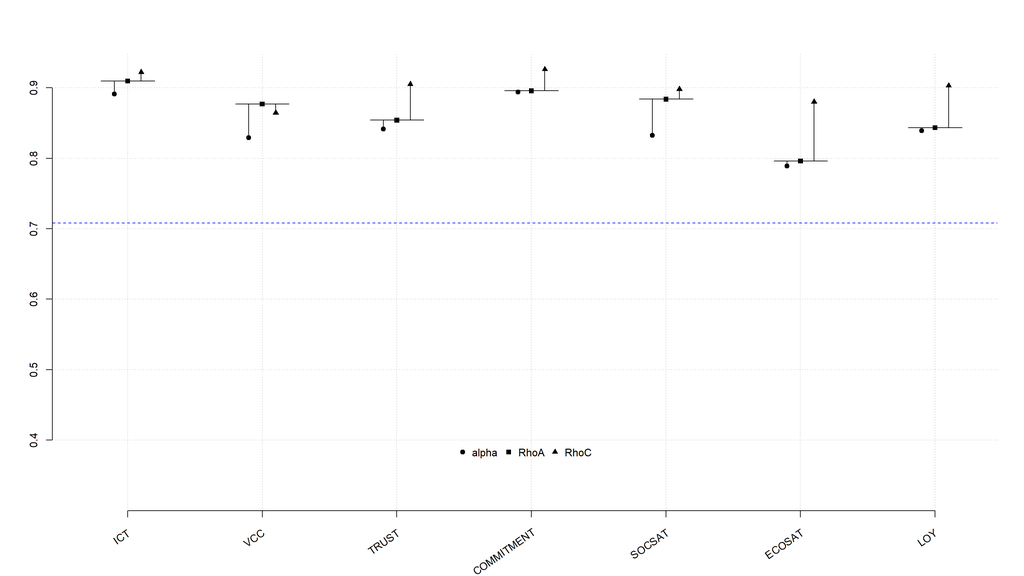

Tabla de fiabilidad

### 2.2.2 Análisis de las cargas

Por otro lado, es importante analizar también las cargas o *loadings*, indicadores de la fiabilidad del indicador en el constructo, y que deberían ser mayores de 0.7 para retener el indicador; para aquellas que están entre 0.4 y 0.7 debe ser analizado el comportamiento del constructo ante una eliminación del indicador con carga baja[^2].

```
              ICT   VCC TRUST COMMITMENT SOCSAT ECOSAT   LOY
ICT1        0.906 0.000 0.000      0.000  0.000  0.000 0.000
ICT2        0.925 0.000 0.000      0.000  0.000  0.000 0.000
ICT3        0.930 0.000 0.000      0.000  0.000  0.000 0.000
ICT4        0.761 0.000 0.000      0.000  0.000  0.000 0.000
ICT5        0.644 0.000 0.000      0.000  0.000  0.000 0.000
VCC1        0.000 0.792 0.000      0.000  0.000  0.000 0.000
VCC2        0.000 0.831 0.000      0.000  0.000  0.000 0.000
VCC3        0.000 0.634 0.000      0.000  0.000  0.000 0.000
VCC4        0.000 0.862 0.000      0.000  0.000  0.000 0.000
VCC5        0.000 0.683 0.000      0.000  0.000  0.000 0.000
VCC6        0.000 0.465 0.000      0.000  0.000 -0.000 0.000
TRUST1      0.000 0.000 0.940      0.000  0.000  0.000 0.000
TRUST2      0.000 0.000 0.804      0.000  0.000  0.000 0.000
TRUST3      0.000 0.000 0.869      0.000  0.000  0.000 0.000
COMMITMENT1 0.000 0.000 0.000      0.858  0.000  0.000 0.000
COMMITMENT2 0.000 0.000 0.000      0.888  0.000  0.000 0.000
COMMITMENT3 0.000 0.000 0.000      0.851  0.000  0.000 0.000
COMMITMENT4 0.000 0.000 0.000      0.885  0.000  0.000 0.000
SOCSAT1     0.000 0.000 0.000      0.000  0.748  0.000 0.000
SOCSAT2     0.000 0.000 0.000      0.000  0.927  0.000 0.000
SOCSAT3     0.000 0.000 0.000      0.000  0.907  0.000 0.000
ECOSAT1     0.000 0.000 0.000      0.000  0.000  0.918 0.000
ECOSAT2     0.000 0.000 0.000      0.000  0.000  0.895 0.000
ECOSAT3     0.000 0.000 0.000      0.000  0.000  0.703 0.000
LOY1        0.000 0.000 0.000      0.000  0.000  0.000 0.890
LOY2        0.000 0.000 0.000      0.000  0.000  0.000 0.835
LOY4        0.000 0.000 0.000      0.000  0.000  0.000 0.883
```

## 2.3 Validez discriminante

### 2.3.1 Cross-loadings

Para el análisis de la validez discriminante o capacidad de un constructo de ser realmente distinto a otros, utilizamos las denominadas *cross-loadings*, que miden esa capacidad del constructo. En la tabla adjunta se puede observar en cada indicador carga de forma superior en su variable latente, siendo el resto de cargas de menor intensidad.

```
              ICT   VCC TRUST COMMITMENT SOCSAT ECOSAT   LOY
ICT1        0.906 0.451 0.081      0.209  0.235  0.248 0.323
ICT2        0.925 0.437 0.122      0.239  0.214  0.250 0.310
ICT3        0.930 0.476 0.142      0.280  0.284  0.331 0.344
ICT4        0.761 0.357 0.076      0.162  0.176  0.263 0.226
ICT5        0.644 0.344 0.084      0.194  0.206  0.055 0.175
VCC1        0.424 0.792 0.434      0.546  0.413  0.612 0.648
VCC2        0.431 0.831 0.321      0.522  0.378  0.551 0.583
VCC3        0.268 0.634 0.079      0.216  0.314  0.109 0.231
VCC4        0.411 0.862 0.354      0.513  0.446  0.439 0.549
VCC5        0.309 0.683 0.131      0.287  0.227  0.106 0.252
VCC6        0.237 0.465 0.132      0.143  0.256 -0.036 0.101
TRUST1      0.103 0.362 0.940      0.546  0.544  0.471 0.488
TRUST2      0.095 0.305 0.804      0.493  0.392  0.486 0.473
TRUST3      0.121 0.335 0.869      0.530  0.488  0.386 0.427
COMMITMENT1 0.248 0.560 0.514      0.858  0.475  0.509 0.610
COMMITMENT2 0.253 0.572 0.520      0.888  0.505  0.527 0.649
COMMITMENT3 0.197 0.393 0.531      0.851  0.467  0.252 0.396
COMMITMENT4 0.207 0.450 0.524      0.885  0.518  0.366 0.475
SOCSAT1     0.219 0.358 0.229      0.329  0.748  0.452 0.447
SOCSAT2     0.222 0.440 0.578      0.524  0.927  0.624 0.629
SOCSAT3     0.258 0.445 0.539      0.568  0.907  0.666 0.728
ECOSAT1     0.198 0.419 0.507      0.443  0.581  0.918 0.623
ECOSAT2     0.211 0.427 0.521      0.479  0.578  0.895 0.622
ECOSAT3     0.307 0.450 0.246      0.282  0.568  0.703 0.543
LOY1        0.290 0.593 0.489      0.549  0.676  0.663 0.890
LOY2        0.281 0.486 0.414      0.499  0.497  0.586 0.835
LOY4        0.303 0.538 0.473      0.560  0.679  0.597 0.883
```

### 2.3.2 Fornell-Larcker

El criterio de Fornell-Larcker, compara la raíz cuadrado del *AVE* con la correlación de las variables latentes. La raíz cuadrada del AVE de cada constructo, debería ser más grande que la más alta correlación con cualquier otro constructo. Se puede observar en la tabla siguiente que el valor en la diagonal principal, es mayor que el resto de valores en la parte inferior de la matriz.

```
             ICT   VCC TRUST COMMITMENT SOCSAT ECOSAT   LOY
ICT        0.841     .     .          .      .      .     .
VCC        0.496 0.724     .          .      .      .     .
TRUST      0.122 0.383 0.873          .      .      .     .
COMMITMENT 0.261 0.570 0.599      0.871      .      .     .
SOCSAT     0.268 0.482 0.548      0.565  0.865      .     .
ECOSAT     0.281 0.512 0.510      0.480  0.684  0.844     .
LOY        0.335 0.622 0.528      0.616  0.712  0.709 0.870

FL Criteria table reports square root of AVE on the diagonal and construct correlations on the lower triangle.
```

### 2.3.3 HTMT

Por último el HTMT es un ratio que si es mayor que 0.90 indica una pérdida de validez discriminante.

```
             ICT   VCC TRUST COMMITMENT SOCSAT ECOSAT LOY
ICT            .     .     .          .      .      .   .
VCC        0.553     .     .          .      .      .   .
TRUST      0.150 0.475     .          .      .      .   .
COMMITMENT 0.290 0.591 0.692          .      .      .   .
SOCSAT     0.313 0.565 0.614      0.634      .      .   .
ECOSAT     0.339 0.584 0.625      0.564  0.832      .   .
LOY        0.382 0.640 0.630      0.706  0.828  0.871   .
```

## 2.4 Análisis del modelo estructural

- R<sup>2</sup>, coeficiente de determinación y/o % de varianza explicada
- f<sup>2</sup> y q<sup>2</sup> efecto tamaño
- Q<sup>2</sup>, relevancia predictiva

### 2.4.1 Colinealidad

Colinealidad, estudiada con los inner VIF value (inverso de la tolerancia). Todos los valores deben ser menores a 0.20 en tolerancia, lo que implica ser menores a 5 en VIF. Los valores se dan para cada constructo.

#### 2.4.1.1 vif items

```
ICT :
 ICT1  ICT2  ICT3  ICT4  ICT5
5.577 7.862 5.074 1.796 1.402

VCC :
 VCC1  VCC2  VCC3  VCC4  VCC5  VCC6
3.056 3.057 2.747 2.385 2.304 2.660

TRUST :
TRUST1 TRUST2 TRUST3
 3.427  1.825  2.452

COMMITMENT :
COMMITMENT1 COMMITMENT2 COMMITMENT3 COMMITMENT4
      2.966       3.256       3.379       3.742

SOCSAT :
SOCSAT1 SOCSAT2 SOCSAT3
  1.569   2.801   2.431

ECOSAT :
ECOSAT1 ECOSAT2 ECOSAT3
  4.052   3.819   1.232

LOY :
 LOY1  LOY2  LOY4
2.168 1.734 2.220
```

#### 2.4.1.2 vif antecedents

```
VCC :
ICT
  .

TRUST :
VCC
  .

COMMITMENT :
  VCC TRUST
1.172 1.172

SOCSAT :
     TRUST COMMITMENT
      1.56       1.56

ECOSAT :
SOCSAT
     .

LOY :
ECOSAT
     .
```

#### 2.4.1.3 Paths

```
             VCC TRUST COMMITMENT SOCSAT ECOSAT   LOY
R^2        0.246 0.147      0.495  0.387  0.468 0.503
AdjR^2     0.243 0.144      0.491  0.382  0.466 0.501
ICT        0.496     .          .      .      .     .
VCC            . 0.383      0.399      .      .     .
TRUST          .     .      0.446  0.327      .     .
COMMITMENT     .     .          .  0.369      .     .
SOCSAT         .     .          .      .  0.684     .
ECOSAT         .     .          .      .      . 0.709
```

### 2.4.2 R<sup>2</sup>

Buscar R<sup>2</sup> mayores de 0.7, aunque valores alrededor de 0.25 sean aceptados según ámbitos; (sustancial mayor que 0.75, moderado alrededor de 0.5 y débil, 0.25). Usar R<sup>2</sup><sub>adj</sub> para comparar modelos con diferente número de constructos y/u observaciones.

```
             VCC     TRUST COMMITMENT    SOCSAT    ECOSAT       LOY
Rsq    0.2457372 0.1469308  0.4950779 0.3873394 0.4676629 0.5029493
AdjRsq 0.2427677 0.1435722  0.4910865 0.3824963 0.4655671 0.5009924
```

### 2.4.3 f<sup>2</sup> - effect sizes

El f<sup>2</sup> permite evaluar la contribución de cada constructo exógeno a la R<sup>2</sup> de un constructo endógeno. Los valores de 0.02, 0.15 y 0.35 indican un efecto pequeño, mediano o grande sobre el constructo endógeno.

```
             ICT   VCC TRUST COMMITMENT SOCSAT ECOSAT   LOY
ICT        0.000 0.326 0.000      0.000  0.000  0.000 0.000
VCC        0.000 0.000 0.172      0.269  0.000  0.000 0.000
TRUST      0.000 0.000 0.000      0.329  0.115  0.000 0.000
COMMITMENT 0.000 0.000 0.000      0.000  0.137  0.000 0.000
SOCSAT     0.000 0.000 0.000      0.000  0.000  0.879 0.000
ECOSAT     0.000 0.000 0.000      0.000  0.000  0.000 1.012
LOY        0.000 0.000 0.000      0.000  0.000  0.000 0.000
```

### 2.4.4 Efectos

#### 2.4.4.1 Totales

```
             ICT   VCC TRUST COMMITMENT SOCSAT ECOSAT   LOY
ICT        0.000 0.496 0.190      0.283  0.166  0.114 0.081
VCC        0.000 0.000 0.383      0.570  0.336  0.229 0.163
TRUST      0.000 0.000 0.000      0.446  0.492  0.336 0.238
COMMITMENT 0.000 0.000 0.000      0.000  0.369  0.252 0.179
SOCSAT     0.000 0.000 0.000      0.000  0.000  0.684 0.485
ECOSAT     0.000 0.000 0.000      0.000  0.000  0.000 0.709
LOY        0.000 0.000 0.000      0.000  0.000  0.000 0.000
```

#### 2.4.4.2 Indirectos

```
             ICT   VCC TRUST COMMITMENT SOCSAT ECOSAT   LOY
ICT        0.000 0.000 0.190      0.283  0.166  0.114 0.081
VCC        0.000 0.000 0.000      0.171  0.336  0.229 0.163
TRUST      0.000 0.000 0.000      0.000  0.164  0.336 0.238
COMMITMENT 0.000 0.000 0.000      0.000  0.000  0.252 0.179
SOCSAT     0.000 0.000 0.000      0.000  0.000  0.000 0.485
ECOSAT     0.000 0.000 0.000      0.000  0.000  0.000 0.000
LOY        0.000 0.000 0.000      0.000  0.000  0.000 0.000
```

### 2.4.5 it_criteria

```
        VCC   TRUST COMMITMENT   SOCSAT   ECOSAT      LOY
AIC -69.198 -37.684   -169.940 -120.428 -158.404 -175.962
BIC -62.107 -30.594   -159.304 -109.792 -151.314 -168.872
```

# 3 Modelización con bootstrapping

*Bootstrapping* para calcular la significatividad de los paths estimados. Habitualmente se trabaja con un 5% (t > 1.96) lo que implica significatividad al 95%. Podemos cambiar al 10 o al 1 según ámbito. Usar doble *bootstrapping* si hay menos de 4 constructos.

```
Bootstrapping model using seminr...
SEMinR Model successfully bootstrapped
```

## 3.1 Structural paths

```
                       Original Est. Bootstrap Mean Bootstrap SD T Stat. 2.5% CI 97.5% CI
ICT  ->  VCC                   0.496          0.500        0.055   8.946   0.386    0.601
VCC  ->  TRUST                 0.383          0.386        0.056   6.881   0.271    0.488
VCC  ->  COMMITMENT            0.399          0.401        0.048   8.288   0.303    0.490
TRUST  ->  COMMITMENT          0.446          0.445        0.054   8.291   0.339    0.549
TRUST  ->  SOCSAT              0.327          0.326        0.076   4.300   0.177    0.475
COMMITMENT  ->  SOCSAT         0.369          0.368        0.082   4.516   0.205    0.524
SOCSAT  ->  ECOSAT             0.684          0.685        0.043  15.887   0.593    0.763
ECOSAT  ->  LOY                0.709          0.711        0.046  15.422   0.611    0.791
```

## 3.2 Bootstrapped weights

```
                            Original Est. Bootstrap Mean Bootstrap SD T Stat. 2.5% CI 97.5% CI
ICT1  ->  ICT                       0.258          0.258        0.015  16.782   0.229    0.289
ICT2  ->  ICT                       0.250          0.249        0.016  15.736   0.217    0.279
ICT3  ->  ICT                       0.272          0.272        0.018  15.331   0.241    0.310
ICT4  ->  ICT                       0.204          0.204        0.029   7.019   0.146    0.259
ICT5  ->  ICT                       0.197          0.196        0.026   7.552   0.144    0.246
VCC1  ->  VCC                       0.318          0.318        0.024  13.282   0.276    0.370
VCC2  ->  VCC                       0.293          0.292        0.020  14.538   0.255    0.334
VCC3  ->  VCC                       0.132          0.130        0.028   4.731   0.072    0.180
VCC4  ->  VCC                       0.292          0.292        0.016  18.191   0.262    0.325
VCC5  ->  VCC                       0.169          0.170        0.024   7.145   0.120    0.213
VCC6  ->  VCC                       0.115          0.113        0.027   4.281   0.056    0.161
TRUST1  ->  TRUST                   0.415          0.414        0.017  25.124   0.382    0.448
TRUST2  ->  TRUST                   0.340          0.343        0.025  13.545   0.295    0.395
TRUST3  ->  TRUST                   0.387          0.386        0.019  19.903   0.346    0.423
COMMITMENT1  ->  COMMITMENT         0.293          0.293        0.015  18.878   0.265    0.326
COMMITMENT2  ->  COMMITMENT         0.302          0.302        0.015  19.738   0.274    0.334
COMMITMENT3  ->  COMMITMENT         0.267          0.267        0.014  19.065   0.240    0.295
COMMITMENT4  ->  COMMITMENT         0.286          0.286        0.013  21.680   0.259    0.311
SOCSAT1  ->  SOCSAT                 0.267          0.267        0.020  13.345   0.226    0.305
SOCSAT2  ->  SOCSAT                 0.428          0.427        0.016  27.507   0.397    0.459
SOCSAT3  ->  SOCSAT                 0.445          0.446        0.016  28.026   0.417    0.479
ECOSAT1  ->  ECOSAT                 0.407          0.408        0.016  25.136   0.379    0.443
ECOSAT2  ->  ECOSAT                 0.406          0.406        0.016  25.850   0.378    0.439
ECOSAT3  ->  ECOSAT                 0.375          0.374        0.022  17.077   0.328    0.415
LOY1  ->  LOY                       0.412          0.412        0.019  21.503   0.378    0.452
LOY2  ->  LOY                       0.365          0.365        0.018  19.865   0.329    0.401
LOY4  ->  LOY                       0.372          0.371        0.018  20.682   0.335    0.407
```

## 3.3 Bootstrapped loadings

```
                            Original Est. Bootstrap Mean Bootstrap SD T Stat. 2.5% CI 97.5% CI
ICT1  ->  ICT                       0.906          0.906        0.016  55.603   0.871    0.934
ICT2  ->  ICT                       0.925          0.925        0.015  62.107   0.890    0.949
ICT3  ->  ICT                       0.930          0.930        0.013  72.676   0.902    0.952
ICT4  ->  ICT                       0.761          0.760        0.049  15.389   0.652    0.843
ICT5  ->  ICT                       0.644          0.643        0.047  13.674   0.543    0.727
VCC1  ->  VCC                       0.792          0.792        0.030  26.373   0.727    0.846
VCC2  ->  VCC                       0.831          0.830        0.034  24.507   0.756    0.890
VCC3  ->  VCC                       0.634          0.628        0.060  10.551   0.496    0.728
VCC4  ->  VCC                       0.862          0.861        0.019  45.454   0.820    0.893
VCC5  ->  VCC                       0.683          0.680        0.053  12.834   0.567    0.774
VCC6  ->  VCC                       0.465          0.460        0.075   6.234   0.298    0.590
TRUST1  ->  TRUST                   0.940          0.940        0.010  90.076   0.917    0.957
TRUST2  ->  TRUST                   0.804          0.806        0.027  29.875   0.751    0.855
TRUST3  ->  TRUST                   0.869          0.866        0.025  34.540   0.810    0.907
COMMITMENT1  ->  COMMITMENT         0.858          0.858        0.022  38.194   0.809    0.897
COMMITMENT2  ->  COMMITMENT         0.888          0.888        0.016  54.259   0.852    0.916
COMMITMENT3  ->  COMMITMENT         0.851          0.851        0.024  35.067   0.799    0.894
COMMITMENT4  ->  COMMITMENT         0.885          0.884        0.020  44.333   0.840    0.918
SOCSAT1  ->  SOCSAT                 0.748          0.746        0.038  19.584   0.665    0.815
SOCSAT2  ->  SOCSAT                 0.927          0.927        0.010  88.877   0.906    0.946
SOCSAT3  ->  SOCSAT                 0.907          0.907        0.013  67.826   0.878    0.930
ECOSAT1  ->  ECOSAT                 0.918          0.918        0.013  73.090   0.893    0.941
ECOSAT2  ->  ECOSAT                 0.895          0.895        0.019  47.352   0.852    0.926
ECOSAT3  ->  ECOSAT                 0.703          0.700        0.043  16.366   0.609    0.774
LOY1  ->  LOY                       0.890          0.891        0.014  64.812   0.862    0.915
LOY2  ->  LOY                       0.835          0.835        0.031  27.128   0.767    0.887
LOY4  ->  LOY                       0.883          0.883        0.018  48.343   0.844    0.914
```

## 3.4 Bootstrapped HTMT

```
                       Original Est. Bootstrap Mean Bootstrap SD T Stat. 2.5% CI 97.5% CI
ICT  ->  VCC                   0.553          0.552        0.065   8.449   0.416    0.672
ICT  ->  TRUST                 0.150          0.164        0.057   2.640   0.071    0.288
ICT  ->  COMMITMENT            0.290          0.291        0.067   4.358   0.160    0.421
ICT  ->  SOCSAT                0.313          0.314        0.075   4.166   0.162    0.456
ICT  ->  ECOSAT                0.339          0.345        0.070   4.834   0.202    0.476
ICT  ->  LOY                   0.382          0.385        0.072   5.310   0.238    0.523
VCC  ->  TRUST                 0.475          0.474        0.052   9.200   0.369    0.571
VCC  ->  COMMITMENT            0.591          0.591        0.044  13.301   0.502    0.677
VCC  ->  SOCSAT                0.565          0.563        0.067   8.432   0.424    0.685
VCC  ->  ECOSAT                0.584          0.599        0.044  13.382   0.516    0.687
VCC  ->  LOY                   0.640          0.644        0.052  12.315   0.540    0.745
TRUST  ->  COMMITMENT          0.692          0.690        0.053  12.984   0.581    0.789
TRUST  ->  SOCSAT              0.614          0.616        0.061  10.066   0.496    0.733
TRUST  ->  ECOSAT              0.625          0.625        0.074   8.495   0.478    0.761
TRUST  ->  LOY                 0.630          0.629        0.070   9.064   0.487    0.756
COMMITMENT  ->  SOCSAT         0.634          0.632        0.068   9.262   0.489    0.760
COMMITMENT  ->  ECOSAT         0.564          0.564        0.068   8.291   0.427    0.694
COMMITMENT  ->  LOY            0.706          0.705        0.049  14.295   0.602    0.795
SOCSAT  ->  ECOSAT             0.832          0.834        0.050  16.699   0.727    0.921
SOCSAT  ->  LOY                0.828          0.827        0.047  17.588   0.726    0.911
ECOSAT  ->  LOY                0.871          0.873        0.055  15.743   0.751    0.965
```

## 3.5 Total effects (paths)

```
                       Original Est. Bootstrap Mean Bootstrap SD T Stat. 2.5% CI 97.5% CI
ICT  ->  VCC                   0.496          0.500        0.055   8.946   0.386    0.601
ICT  ->  TRUST                 0.190          0.193        0.037   5.134   0.121    0.266
ICT  ->  COMMITMENT            0.283          0.287        0.038   7.449   0.210    0.360
ICT  ->  SOCSAT                0.166          0.169        0.030   5.491   0.112    0.232
ICT  ->  ECOSAT                0.114          0.116        0.024   4.697   0.072    0.168
ICT  ->  LOY                   0.081          0.083        0.020   4.005   0.048    0.127
VCC  ->  TRUST                 0.383          0.386        0.056   6.881   0.271    0.488
VCC  ->  COMMITMENT            0.570          0.573        0.037  15.431   0.496    0.642
VCC  ->  SOCSAT                0.336          0.339        0.046   7.364   0.248    0.427
VCC  ->  ECOSAT                0.229          0.233        0.039   5.913   0.157    0.311
VCC  ->  LOY                   0.163          0.166        0.034   4.763   0.102    0.237
TRUST  ->  COMMITMENT          0.446          0.445        0.054   8.291   0.339    0.549
TRUST  ->  SOCSAT              0.492          0.489        0.060   8.218   0.368    0.605
TRUST  ->  ECOSAT              0.336          0.336        0.049   6.863   0.242    0.434
TRUST  ->  LOY                 0.238          0.240        0.044   5.466   0.161    0.330
COMMITMENT  ->  SOCSAT         0.369          0.368        0.082   4.516   0.205    0.524
COMMITMENT  ->  ECOSAT         0.252          0.253        0.060   4.229   0.136    0.369
COMMITMENT  ->  LOY            0.179          0.181        0.047   3.764   0.091    0.277
SOCSAT  ->  ECOSAT             0.684          0.685        0.043  15.887   0.593    0.763
SOCSAT  ->  LOY                0.485          0.489        0.058   8.346   0.369    0.594
ECOSAT  ->  LOY                0.709          0.711        0.046  15.422   0.611    0.791
```

## 3.6 Plot model

[interactive chart not shown]

Modelo con bootstrapping

# 4 Predicción (seminr)

```
PLS in-sample metrics:
      VCC1  VCC2  VCC3  VCC4  VCC5  VCC6 TRUST1 TRUST2 TRUST3 COMMITMENT1 COMMITMENT2 COMMITMENT3 COMMITMENT4 SOCSAT1 SOCSAT2 SOCSAT3 ECOSAT1 ECOSAT2 ECOSAT3  LOY1  LOY2  LOY4
RMSE 1.683 1.444 1.487 1.351 1.152 1.328  0.767  1.239  0.736       1.088       0.865       0.841       0.874   0.915   0.734   0.899   1.240   1.232   1.147 0.859 1.255 0.929
MAD  1.434 1.169 1.200 1.083 0.913 1.103  0.580  1.025  0.566       0.861       0.708       0.613       0.653   0.707   0.558   0.682   0.994   0.988   0.800 0.670 0.979 0.694

PLS out-of-sample metrics:
      VCC1  VCC2  VCC3  VCC4  VCC5  VCC6 TRUST1 TRUST2 TRUST3 COMMITMENT1 COMMITMENT2 COMMITMENT3 COMMITMENT4 SOCSAT1 SOCSAT2 SOCSAT3 ECOSAT1 ECOSAT2 ECOSAT3  LOY1  LOY2  LOY4
RMSE 1.693 1.450 1.506 1.369 1.166 1.344  0.777  1.250  0.747       1.100       0.880       0.850       0.886   0.924   0.746   0.915   1.247   1.243   1.156 0.873 1.266 0.947
MAD  1.442 1.175 1.214 1.095 0.925 1.118  0.584  1.037  0.574       0.871       0.718       0.618       0.661   0.714   0.564   0.693   0.998   0.996   0.807 0.677 0.990 0.703

LM in-sample metrics:
      VCC1  VCC2  VCC3  VCC4  VCC5  VCC6 TRUST1 TRUST2 TRUST3 COMMITMENT1 COMMITMENT2 COMMITMENT3 COMMITMENT4 SOCSAT1 SOCSAT2 SOCSAT3 ECOSAT1 ECOSAT2 ECOSAT3  LOY1  LOY2  LOY4
RMSE 1.073 1.064 1.140 1.065 0.978 1.014  0.567  0.807  0.564       0.897       0.747       0.727       0.791   0.621   0.561   0.629   0.900   0.875   0.856 0.664 1.069 0.694
MAD  0.856 0.851 0.892 0.868 0.772 0.784  0.446  0.633  0.453       0.694       0.599       0.539       0.577   0.487   0.438   0.492   0.715   0.689   0.636 0.512 0.852 0.537

LM out-of-sample metrics:
      VCC1  VCC2  VCC3  VCC4  VCC5  VCC6 TRUST1 TRUST2 TRUST3 COMMITMENT1 COMMITMENT2 COMMITMENT3 COMMITMENT4 SOCSAT1 SOCSAT2 SOCSAT3 ECOSAT1 ECOSAT2 ECOSAT3  LOY1  LOY2  LOY4
RMSE 1.216 1.206 1.318 1.246 1.187 1.158  0.664  0.971  0.649       1.058       0.870       0.881       0.943   0.751   0.657   0.799   1.042   1.039   1.060 0.830 1.304 0.868
MAD  0.965 0.953 1.014 1.005 0.889 0.879  0.510  0.738  0.517       0.808       0.688       0.628       0.664   0.566   0.502   0.593   0.817   0.808   0.742 0.612 1.002 0.637
```

# 5 Relevancia predictiva (matrixpls)

(con matrixpls -Aldás y Uriel, 2017-)

```
 matrixpls parameter estimates
                              Est.
ICT~VCC                 0.49442972
VCC~TRUST               0.06001261
VCC~COMMITMENT          0.52983407
TRUST~COMMITMENT        0.42381669
TRUST~SOCSAT            0.31028875
COMMITMENT~SOCSAT       0.56550865
SOCSAT~ECOSAT           0.68430620
ECOSAT~LOY              0.70914209
ICT=~ICT1               0.90513854
ICT=~ICT2               0.92439220
ICT=~ICT3               0.92939682
ICT=~ICT4               0.76149371
ICT=~ICT5               0.64670076
VCC=~VCC1               0.77919258
VCC=~VCC2               0.82396903
VCC=~VCC3               0.64859352
VCC=~VCC4               0.86144742
VCC=~VCC5               0.69585730
VCC=~VCC6               0.48002887
TRUST=~TRUST1           0.93999597
TRUST=~TRUST2           0.80403517
TRUST=~TRUST3           0.86902155
COMMITMENT=~COMMITMENT1 0.85896985
COMMITMENT=~COMMITMENT2 0.88828035
COMMITMENT=~COMMITMENT3 0.85077747
COMMITMENT=~COMMITMENT4 0.88464525
SOCSAT=~SOCSAT1         0.74367731
SOCSAT=~SOCSAT2         0.92857739
SOCSAT=~SOCSAT3         0.90883267
ECOSAT=~ECOSAT1         0.91824312
ECOSAT=~ECOSAT2         0.89508386
ECOSAT=~ECOSAT3         0.70208563
LOY=~LOY1               0.89031270
LOY=~LOY2               0.83524603
LOY=~LOY4               0.88290424

 matrixpls weights
                ICT1      ICT2      ICT3      ICT4      ICT5     VCC1      VCC2      VCC3      VCC4      VCC5      VCC6    TRUST1    TRUST2    TRUST3 COMMITMENT1 COMMITMENT2 COMMITMENT3 COMMITMENT4   SOCSAT1  SOCSAT2   SOCSAT3   ECOSAT1   ECOSAT2   ECOSAT3      LOY1      LOY2      LOY4
```

[output cut: 106 more lines]

```
ICT        0.0000000 0.0000000 0.0000000  0.0000000 0.0000000 0.0000000 0.0000000
VCC        0.5529984 0.0000000 0.0000000  0.0000000 0.0000000 0.0000000 0.0000000
TRUST      0.1395340 0.3885449 0.0000000  0.0000000 0.0000000 0.0000000 0.0000000
COMMITMENT 0.2901720 0.5855432 0.6921706  0.0000000 0.0000000 0.0000000 0.0000000
SOCSAT     0.3126115 0.5653729 0.6143936  0.6343595 0.0000000 0.0000000 0.0000000
ECOSAT     0.3319744 0.5057293 0.6253619  0.5636538 0.8324163 0.0000000 0.0000000
LOY        0.3822888 0.6402719 0.6302629  0.7061534 0.8284748 0.8712458 0.0000000

 Composite equilevance indices

 CEI individual
       ICT        VCC      TRUST COMMITMENT     SOCSAT     ECOSAT        LOY
 0.9987251  0.9736375  0.9994813  0.9998145  0.9942532  0.9997501  0.9997672

 CEI total: 0.9736375
```

```
 Q2 predictive relevance statistics

 Overall Q2
0.2466603
 Block Q2
        ICT         VCC       TRUST  COMMITMENT      SOCSAT      ECOSAT         LOY
 0.06302256  0.21601147  0.42854701  0.24552913 -0.17005699  0.51870178  0.62816953

 Indicator Q2
      TRUST1       TRUST2       TRUST3  COMMITMENT1  COMMITMENT2  COMMITMENT3  COMMITMENT4         VCC1         VCC2         VCC3         VCC4         VCC5         VCC6      ECOSAT1      ECOSAT2      ECOSAT3      SOCSAT1      SOCSAT2      SOCSAT3         LOY1         LOY2         LOY4         ICT1  …
 0.412679074  0.497685624 -0.463315270  0.281604015  0.346803748 -0.038676822  0.088628805  0.214117000  0.141999270  0.289640910  0.014433770  0.172031666  0.385428624  0.555000476  0.567568176  0.265751334 -0.380149369 -1.480450679  0.437828577  0.788548963  0.498933590  0.826393375  0.049209913  …
```

# 6 Potencia (matrixpls)

```
     Multiple regression power calculation

              u = 6
              v = 250
             f2 = 0.15
      sig.level = 0.05
          power = 0.9990871
```

```
     Multiple regression power calculation

              u = 6
              v = 90.30998
             f2 = 0.15
      sig.level = 0.05
          power = 0.8
```

[^1]: En https://forum.smartpls.com/viewtopic.php?f=5&t=3805 hay una “discusión en torno al”greater than 0.9" de Primer PLS … de Hair; lo solventa un investigador / desarrollador de SmartPLS: https://www.researchgate.net/profile/Jan_Michael_Becker
[^2]: En nuestro caso al proceder con la eliminación de aquellas cargas menores de 0.7 no mejoraba significativamente el modelo